# Alignment & batch integration of single cell data with corralm

Lauren Hsu

Harvard School of Public Health; Dana-Farber Cancer Institute

4/28/2020

# 1 Introduction

Data from different experimental platforms and/or batches exhibit systematic variation – i.e., batch effects. Therefore, when conducting joint analysis of data from different batches, a key first step is to align the datasets.

`corralm` is a multi-table adaptation of correspondence analysis designed for single-cell data, which applies multi-dimensional optimized scaling and matrix factorization to compute integrated embeddings across the datasets. These embeddings can then be used in downstream analyses, such as clustering, cell type classification, trajectory analysis, etc.

# 2 Loading packages and data

We will use the `SCMixology` datasets from the *CellBench* package (Tian et al. 2019).

```r
library(corral)
library(SingleCellExperiment)
library(ggplot2)
library(CellBench)

scmix_dat <- load_all_data()[1:3]
```

These datasets include a mixture of three cell lines:

- H2228
- H1975
- HCC827

which was sequenced using three platforms:

- 10X
- CELseq2
- Dropseq

```r
scmix_dat
```

```
## $sc_10x
## class: SingleCellExperiment
## dim: 16468 902
## metadata(3): scPipe Biomart log.exprs.offset
## assays(2): counts logcounts
## rownames(16468): ENSG00000272758 ENSG00000154678 ... ENSG00000054219
##   ENSG00000137691
## rowData names(0):
## colnames(902): CELL_000001 CELL_000002 ... CELL_000955 CELL_000965
## colData names(13): unaligned aligned_unmapped ... outliers cell_line
## reducedDimNames(0):
## spikeNames(0):
## altExpNames(0):
##
## $sc_celseq
## class: SingleCellExperiment
## dim: 28204 274
## metadata(3): scPipe Biomart log.exprs.offset
## assays(2): counts logcounts
## rownames(28204): ENSG00000281131 ENSG00000227456 ... ENSG00000148143
##   ENSG00000226887
## rowData names(0):
## colnames(274): A1 A10 ... P8 P9
## colData names(14): unaligned aligned_unmapped ... outliers cell_line
## reducedDimNames(0):
## spikeNames(1): ERCC
## altExpNames(0):
##
## $sc_dropseq
## class: SingleCellExperiment
## dim: 15127 225
## metadata(3): scPipe Biomart log.exprs.offset
## assays(2): counts logcounts
## rownames(15127): ENSG00000223849 ENSG00000225355 ... ENSG00000133789
##   ENSG00000146674
## rowData names(0):
## colnames(225): CELL_000001 CELL_000002 ... CELL_000249 CELL_000302
## colData names(13): unaligned aligned_unmapped ... outliers cell_line
## reducedDimNames(0):
## spikeNames(0):
## altExpNames(0):
```

Each sequencing platform captures a different set of genes. In order to apply this method, the matrices need to be matched by features (i.e., genes). We’ll find the intersect of the three datasets, then subset for that as we proceed.

First, we will also add to the colData the sequencing platform.

```r
colData(scmix_dat[[1]])$Method <- rep('10X',dim(colData(scmix_dat[[1]]))[1])
colData(scmix_dat[[2]])$Method <- rep('CELseq2',dim(colData(scmix_dat[[2]]))[1])
colData(scmix_dat[[3]])$Method <- rep('Dropseq',dim(colData(scmix_dat[[3]]))[1])

scmix_genes.use <- intersect(rownames(scmix_dat[[1]]),rownames(scmix_dat[[2]]))
scmix_genes.use <- intersect(rownames(scmix_dat[[3]]),scmix_genes.use)

scmix_dat <- lapply(scmix_dat,'[',scmix_genes.use)

# verifying that the genes are all in the same order across the objects
identical(rownames(scmix_dat[[1]]),rownames(scmix_dat[[2]]))
```

```
## [1] TRUE
```

```r
identical(rownames(scmix_dat[[2]]),rownames(scmix_dat[[3]]))
```

```
## [1] TRUE
```

`corralm` can be applied to the following types of objects:

- **a single *SingleCellExperiment*** requires specifying `splitby` (also see documentation of `corralm_matlist` for additional optional arguments that can be passed), which is a character string for the attribute in `colData` that is tracking the batches. In our case, this would be the “Method” attribute we just added. The output from this type of input is the same `SingleCellExperiment`, with the result added to the `reducedDim` slot under `corralm`.
- **a list of *SingleCellExperiment*** does not require any specific arguments. The output is a list of the input `SingleCellExperiment`s, with the result added to the `reducedDim` slot under `corralm`.
- **a list of matrices** (or other matrix-like objects: matrix, Matrix, tibble, data.frame, etc.) also does not require specific arguments. The output will be a concatenated list of SVD output matrices (`u`,`d`,`v`) where `v` contains a concatenated vector of the embeddings for the cells

For purposes of illustration, we will walk through using `corralm` with a single SCE, and with a list of matrices.

# 3 `corralm` on a single *SingleCellExperiment*

First, setting up the data to demonstrate this:

```r
colData(scmix_dat[[2]])$non_ERCC_percent <- NULL # need to remove this column so the objects can be concatenated
scmix_sce <- SingleCellExperiment::cbind(scmix_dat[[1]],scmix_dat[[2]],scmix_dat[[3]])
```

Running `corralm`, and specifying the `splitby` argument: (Note that the default is for the `counts` matrix to be used. To change this default, use the `whichmat` argument.)

```r
scmix_sce <- corralm(scmix_sce, splitby = 'Method')
```

Visualizing the results:

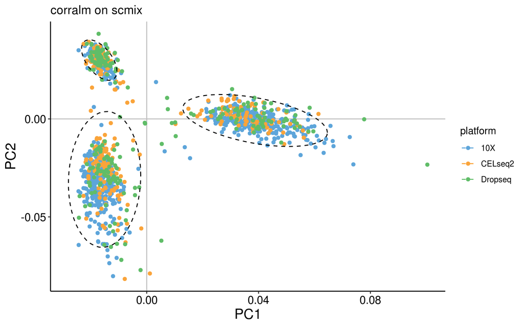

```r
plot_embedding_sce(sce = scmix_sce, which_embedding = 'corralm', color_attr = 'Method', color_title = 'platform', ellipse_attr = 'cell_line', plot_title = 'corralm on scmix', saveplot = FALSE)
```

# 4 `corralm` on a list of matrices

Again, preparing the data to be in this input format:

```r
scmix_matlist <- sce2matlist(sce = scmix_sce, splitby = 'Method', whichmat = 'counts')

# for plotting purposes later, while we're here
platforms <- colData(scmix_sce)$Method
cell_lines <- colData(scmix_sce)$cell_line
```

Running corralm and visualizing output… (the embeddings are in the `v` matrix because these data are matched by genes in the rows and have cells in the columns; if this were reversed, with cells in the rows and genes/features in the column, then the cell embeddings would instead be in the `u` matrix.)

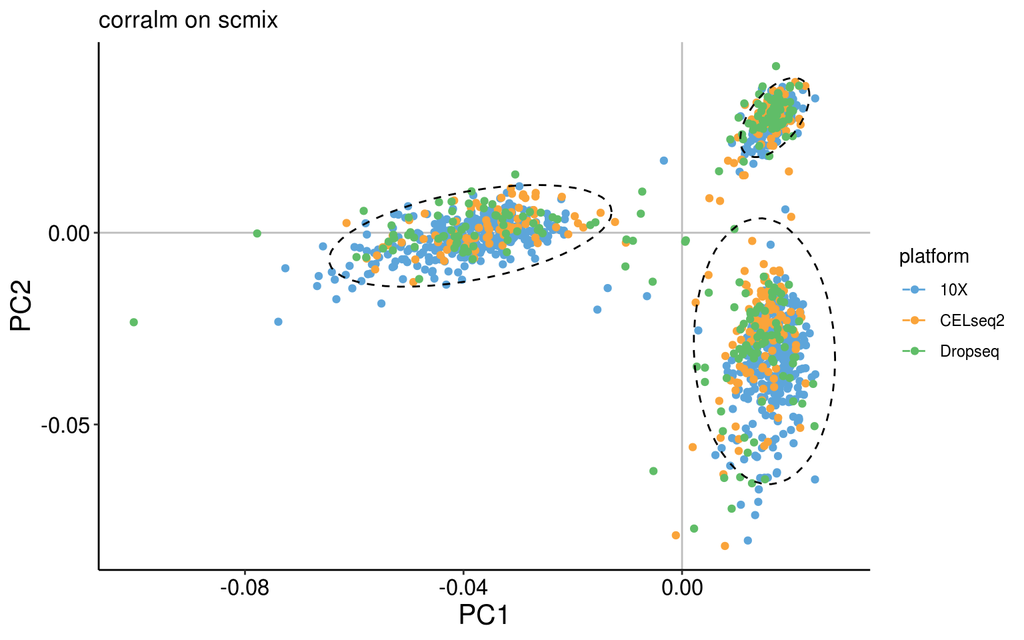

```r
scmix_corralm <- corralm(scmix_matlist)
plot_embedding(embedding = scmix_corralm$v, plot_title = 'corralm on scmix', color_vec = platforms, color_title = 'platform', ellipse_vec = cell_lines, saveplot = FALSE)
```

# References

Tian, Luyi, Xueyi Dong, Saskia Freytag, Kim-Anh Lê Cao, Shian Su, Abolfazl JalalAbadi, Daniela Amann-Zalcenstein, et al. 2019. “Benchmarking Single Cell RNA-Sequencing Analysis Pipelines Using Mixture Control Experiments.” *Nature Methods* 16 (6): 479–87. doi:10.1038/s41592-019-0425-8.